# Common Discrete Distributions

### Facts about the normal distribution

The normal distribution is a bit unique in that it’s summary statistics *are derived* from the distribution parameters (and not the other way around as for other distributions):

$$E[X] = \mu$$
$$V[X] = \sigma^2$$
Calculating normal probabilities manually is not practical due to the form of the density function. Fortunately, we don’t have to calculate normal probabilities manually, as we can use R’s *pnorm*, *qnorm*, and *rnorm* functions.

### The Normal Distribution in Use

The normal distribution is frequently used in quality management applications. For example, assume that the weight of a bag of potato chips filled by machine at the Frito Lay plant follows a normal distribution with mean $\mu = 14.52 \thinspace oz$ and standard deviation $\sigma = 0.11 \thinspace oz$. In order to avoid problems with the U.S. Department of Weights and Measures, the plant needs to ensure that bags are filled to $14.5\thinspace oz \pm 0.25\thinspace oz$. How confident is the plant that it will not have a problem?

One approach would be to determine the lower and upper bounds of various confidence intervals:

```r
mu = 14.52
sigma = 0.11

alpha = c(0.95, 0.98, 0.99)
loweralpha = (1 - alpha) / 2
upperalpha = 1 - loweralpha

lower = qnorm(loweralpha, mu, sigma)
upper = qnorm(upperalpha, mu, sigma)

data.frame(alpha, lower, upper)
```

```
##   alpha    lower    upper
## 1  0.95 14.30440 14.73560
## 2  0.98 14.26410 14.77590
## 3  0.99 14.23666 14.80334
```

From our output, we can see that Frito Lay can be 98% sure that the bag will not be underfilled, but only 95% sure that the bag will not be overfilled.

Alternatively, we can calculate the lower and upper confidence values directly:

```r
mid = 14.5
range = 0.5

probbelow = pnorm(mid - range / 2, mu, sigma)
probabove = pnorm(mid + range / 2, mu, sigma)

alpha = probabove - probbelow
cat('confidence: ', alpha)
```

```
## confidence:  0.9746788
```

```r
loweralpha = 1 - pnorm(mid - range / 2, mu, sigma)
upperalpha = 1 - (1 - pnorm(mid + range / 2, mu, sigma))
```

### Learning More

You can learn about the normal distribution in more detail from lecture notes *14 - The Normal Distribution*.

## The Exponential Distribution

A random variable following an exponential distribution can assume only *non-negative real values*. The exponential distribution also exhibits the Markovian property, meaning the probability of an event is independent of any prior event. In other words, $Pr\{X_2 = x_2|X_1 = x_1\} = Pr\{X_2 = x_2\}$. Exponential distributions are frequently used to model the time between occurrences of an event.

The exponential distribution is described by a single rate parameter, usually denoted $\lambda$ (or sometimes $\mu$) which specifies average number of occurrences per interval (frequently a unit of time, e.g. 15 customers per hour).

The exponential distribution has a characteristic shape:

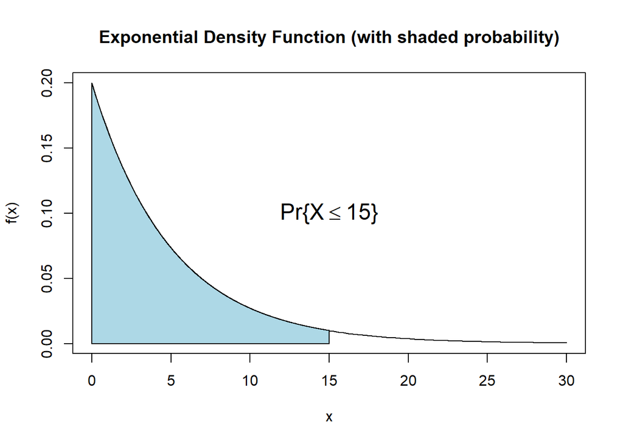

### Relationship to the Poisson distribution

The exponential and Poisson distributions enjoy a unique relationship:

> If the *time* between two events follows an exponential distribution with rate $\lambda$, then the *number* of events per interval follows a Poisson distribution with the same rate $\lambda$, and vice versa.

### Facts about the exponential distribution

The following are facts about a random variable $X$ that follows an exponential distribution with rate $\lambda$:

$$E[X] =\mu= \frac{1}{\lambda}$$
$$V[X] =\sigma^2 = \frac{1}{\lambda^2}$$
$$S[x] = \sigma = \frac{1}{\lambda}$$

$$f(x) = \lambda e^{-\lambda x}$$

$$F(x) = 1 - e^{-\lambda x}$$
$$F^{-1}(\alpha) = \frac{-ln(1-\alpha)}{\lambda}$$
R’s distribution abbreviation for the exponential distribution is *exp* (e.g. pexp, qexp, etc.).

### The Exponential Distribution in Use

Consider a concession at T-Mobile Park in Seattle (formerly Safeco Field) that estimates that customers arrive during the fourth inning at a rate of $25 \frac{cust}{hr}$. A customer has just arrived. What is the probability that another customer arrives in the next 30 seconds?

For this problem, we are trying to calculate a cumulative exponential probability:

$$Pr\{T \leq 30\thinspace secs\}$$

Note here that we want to calculate a probability for a *time* in *seconds*, but our rate, $\lambda$, has a time interval of *hours*. We’ll will need to convert either our time to match $\lambda's$ interval or $\lambda$ to match our desired time interval.

Using the first approach:

$$t_{\lambda} = 30\thinspace secs \cdot \frac{1 \thinspace hr}{3600 \thinspace secs} = \frac{1}{120} hr$$
And we can then calculate the probability that the next customer arrives in 30 seconds or less:

```r
tlambda<-30 / 3600
pexp(tlambda, 25)
```

```
## [1] 0.1880637
```

So $F(30 sec) = 0.1881$. Now, using the second approach we have:

$$\lambda_{secs} = \lambda \cdot \frac{1\thinspace hr}{3600 \thinspace secs} = \frac{25}{3600} \frac{cust}{sec}$$
In R, we have

```r
lambdasecs<-25/3600
x<-30

pexp(x, lambdasecs)
```

```
## [1] 0.1880637
```

As expected, the two approach yield the same answer: the probability a customer arrives in the next 30 seconds is approximately $0.1881$.

### Learning More

For more information on the exponential distribution, see *“15 - The Exponential Distribution and Sums of Random Variables”*.

### The Shifted Exponential Distribution

The shifted exponential is a real-valued distribution with two parameters:

- Rate $\lambda$
- Lower bound $a$

The exponential distribution is a special case of the *Shifted Exponential* distribution where the lower bound $a = 0$. Therefore, if we picture shifting the exponential distribution left or right by $a$, we have a *shifted exponential*.

For example, the following shows a shifted distribution with $a = 5$ and $\lambda = \frac{1}{5}$:

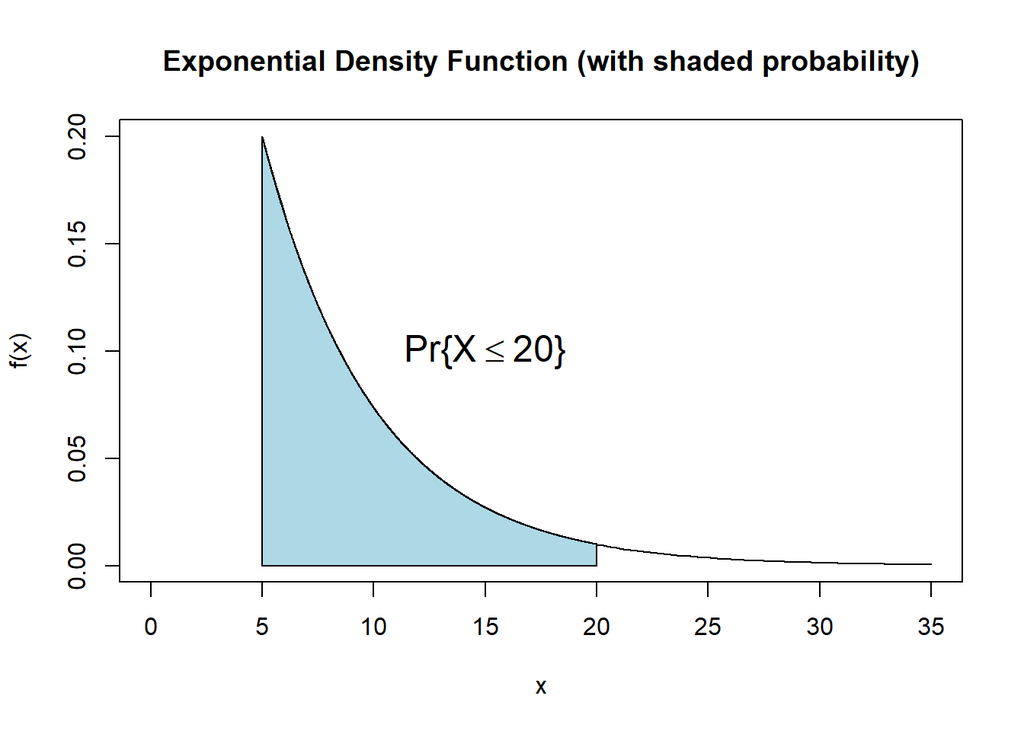

This distribution appears identical to the exponential distribution with $\lambda = 1/5$ we saw previously, except it has been shifted to the right by $a = 5$.

### Facts about the Shifted Exponential Distribution

The following facts about the Shifted Exponential:

$$E[X] =\mu= \frac{1}{\lambda} + a$$
$$V[X] =\sigma^2 = \frac{1}{\lambda^2}$$

$$S[x] = \sigma = \frac{1}{\lambda}$$

$$f(x) = \lambda e^{-\lambda (x-a)}$$

$$F(x) = 1 - e^{-\lambda (x-a)}$$
$$F^{-1}(\alpha) = a-\frac{ln(1-\alpha)}{\lambda}$$

### The Shifted Exponential Distribution in R

To calculate probabilities for a shifted exponential distribution in R, we use R’s exponential distribution functions and account for the shift. To illustrate, let:

- $F_a(x)$ be the cumulative distribution function for a shifted exponential distribution with lower bound $a=5$ and rate $\lambda = 1/5$
- $F_0(x)$ be the cumulative distribution function for an exponential distribution with rate $\lambda = 1/5$

Then

$$F_a(x) = F_0(x-a)$$

$$F_a^{-1}(\alpha) = a + F_0^{-1}(\alpha)$$
In R, this means that to calculate $F_a(20)$ for the shifted exponential, calculate $F_0(20-a)$ for a standard exponential with the same rate $\lambda$:

```r
a<-5
lambda<-1/5

# calculate Pr{X <= 20}

pexp(20-a, lambda)
```

```
## [1] 0.9502129
```

Similarly, to calculate $F_a^{-1}(0.95)$ for a shifted exponential, calculate $a + F_0(0.95)$:

```r
a + qexp(0.95, lambda)
```

```
## [1] 19.97866
```

## The Continuous Uniform Distribution

The continuos uniform distribution is easily handled in R, either using the builtin functions or the uniform distribution’s simple formulas. It is a real-valued distribution with lower bound $a$ and upper bound $b$ (so it is bounded both above and below).

The shape of the continuous distribution reflects the fact that every outcome between $a$ and $b$ is equally likely:

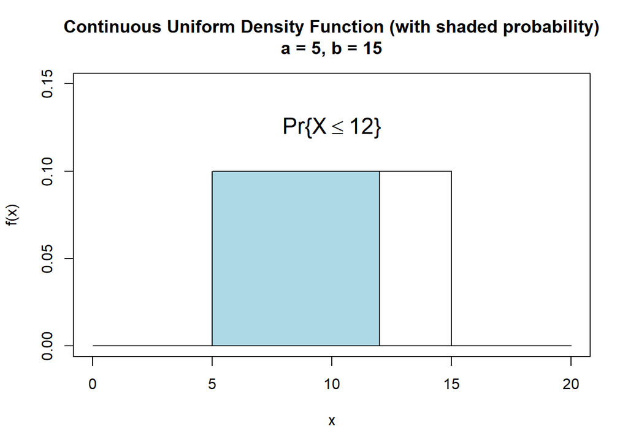

### Facts about the Continuous Uniform Distribution

$$f(x) = \frac{1}{b-a}$$
$$F(x) = Pr\{X \leq x\} = \frac{x-a}{b-a}$$
$$\bar{F}(x) = \frac{b-x}{b-a}$$
$$E[x] = \mu = \frac{a+b}{2}$$

$$V[X] = \sigma^2 = \frac{(b-a)^2}{12}$$

$$S[x] = \sigma = \sqrt{\frac{(b-a)^2}{12}}$$

$$F^{-1}(\alpha) = a + (b-a)\alpha$$

### The Continuous Uniform Distribution in Use

Let’s say that Ford Motor Company has an automated threading process on its assembly line. The process cuts the threads in a threaded rod. The number of complete thread revolutions follows a uniform distribution process with a lower bound of 10 and an upper bound of 10.33.

Determine the mean and standard deviation for complete thread revolutions. For a thread rod chosen at random, what is the probability that the rod has more than 10.25 complete revolutions?

Calculating the mean and standard deviation is easily done using our *facts*:

```r
a<-10
b<-10.33

mu<-(a + b) / 2
cat("mu: ", mu, "\n")
```

```
## mu:  10.165
```

```r
sigma<-sqrt((b-a)^2 / 12)
cat("sigma: ", sigma, "\n")
```

```
## sigma:  0.09526279
```

Thus an *average* threaded rod will have $10.165$ completed threaded revolutions with a standard deviation of $0.0952628$ revolutions.

For the continuous uniform distribution, we have an easy *direct* calculation for $\bar{F}(x)$:

$$\bar{F}(10.25) = \frac{b-x}{b-a}=\frac{10.33 - 10.25}{10.33-10.0} \approx 0.2424$$

If we want to be 95% sure about the *minimum$ number of threaded revolutions for a rod chosen at random, we would calculate:

$$F^{-1}(1-0.95) = a + (b-a) \cdot 0.05$$
In answering this question, we must recognize that we do not have a calculation to directly yield

$$x : Pr\{X >= x\} = \alpha$$

However, we know that $Pr\{X >= x\} = 1 - Pr\{X <= x\}$ and from it follows that:

$$x : Pr\{X >= x\} = \alpha$$
is equivalent to:

$$x : Pr\{X <= x\} = 1-\alpha$$
Thus, in R, we calculate:

```r
alpha<-0.95
a + (b-a)*(1-alpha)
```

```
## [1] 10.0165
```